# Session 2 - Notebook 4

## 5: Signal processing and analysis

In order to extract useful information on our signal, we may want to do some simple analysis of the acquired waveform.

For simple waveforms, for example a simple sinusoid as we are using at the moment, we can in principle extract information on the waveform by fitting the data, as you have learned to do elsewhere.

For more complicated signals we can find information on the signals by using the 'Fast Fourier Transform' (FFT). You may well already know what a Fourier Transform is; the FFT is the same idea, but applied to discrete data rather than continuous functions. If you don't already understand Fourier transforms well, the important point to understand is that the FFT allows us to take data measured in the **time** domain (i.e. voltage vs. time), and convert it into a **spectrum** in the **frequency** domain (amplitude vs. frequency). This allows us to determine the amplitudes of the **frequency components** (sinusiodal waves at specific frequencies), and their phases, that can be used as an alternative description of the data; Fourier Transforms are not only nifty maths, they are also really useful!

An implementation of the FFT is included in scipy: we will use either the newer `scipy.fft.fft` function (https://docs.scipy.org/doc/scipy/reference/fft.html#module-scipy.fft) or, on systems where this fails to load (mine!) the older, entirely compatible, `scipy.fftpack.fft` function (https://docs.scipy.org/doc/scipy/reference/generated/scipy.fftpack.fft.html#scipy.fftpack.fft).

```python
def FFT(signal, time, plot=True):
    '''
    Determine and plot (positive frequency) FFT of signal with timebase time (both numpy arrays).
    Returns frequency and amplitude of (non-zero frequency) fundamental tone.
    '''
    try:
        from scipy.fft import fft
    except ModuleNotFoundError:
        from scipy.fftpack import fft
    import numpy as np
    import matplotlib.pyplot as plt

    fft_signal = fft(signal) # complex FFT spectrum

    yf = 2.0/len(signal) * np.abs(fft_signal[:len(signal)//2])[1:]
    xf = np.linspace(0.0, len(time)/(2.0*(time[-1]-time[0])), len(time)//2)[1:]
    phase = np.angle(fft_signal[1:len(signal)//2]) + np.pi/2

    peak_freq = xf[np.argmax(yf)]
    amplitude = np.max(yf)

    if plot:
        plt.figure(figsize=(6,3))
        plt.plot(xf, yf)
        plt.xlabel('Frequency (Hz)')
        plt.ylabel('Amplitude')
        plt.show()

        print('Fundamental frequency at {} Hz, with amplitude {} V.'.format(peak_freq, amplitude))
        print('Nyquist frequency as last point in FFT = {}'.format(xf[-1]))

    return xf, yf, phase
```

There is no need to understand in detail what this does, but an overview is given below.

In determining `yf`, the normalised amplitudes:

- `fft(signal)` produces a numpy array of (complex) Fourier amplitudes. The first half of the array are amplitudes for frequencies ranging from 0 to the Nyquist frequency, the second half are corresponding 'negative' frequencies, which are discarded using the 'slice' `[:len(signal)//2]`.
- `numpy.abs(...)` then gives the magnitude of the positive frequency complex amplitudes, and we then discard the first (zero-frequency) value with `[1:]` as this will dominate in any signal with 'constant' regions.
- `2.0/len(signal)` is a normalisation.

In determining `xf`, the frequencies:

- `len(time)/(2.0*(time[-1]-time[0]))` is the Nyquist frequency
- `len(time)//2` is the number of elements in the positive-frequency FFT spectrum, and we again remove the element at zero frequency with `[1:]`.

Note that the **more samples** we take, the smaller the discrete frequency spacing in `xf` and hence the **resolution** of the frequency components will be **improved**.

The phase is calculated as the argument of the complex FFT at each point. We add $\pi /2$ to give the correct angle convention.

To test that this works as we expect, we will use an example sine wave, modelling data similar to what we measure; with a frequency of 88 Hz and arbitrary amplitude of 1.5 V, with a measurement duration of 0.1 seconds and consisting of 200 samples:

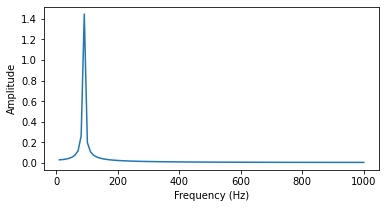

```
Fundamental frequency at 90.9090909090909 Hz, with amplitude 1.444826975239411 V.
Nyquist frequency as last point in FFT = 1000.0
```

```python
import numpy

frequency = 88
amplitude = 1.5
duration = 0.1
samples = 200

time = numpy.linspace(0, duration, samples)
test_signal = amplitude*numpy.sin(2*numpy.pi*frequency*time)

_ = FFT(test_signal, time)
```

Note that the returned fundamental frequency is a little off the input value, and the amplitude is a little lower than input; this is due to the discretisation of the frequencies returned from the FFT - with only 100 points (`samples//2`) between 0 and the Nyquist frequency (1000 Hz) giving a resolution of only ~10 Hz: This is approcimately the width of the peak in the plotted FFT amplitude.

**Note** also that the values returned are not reported to a sensible number of significant figures - another example where (hopefully) scientists understand significant figures better than numpy/scipy!

The resolution of the FFT spectrum can be **improved** by making a **larger number** of samples - at the **same** sample rate:

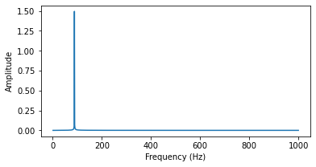

```
Fundamental frequency at 88.0880880880881 Hz, with amplitude 1.4948441956705754 V.
Nyquist frequency as last point in FFT = 1000.0
```

```python
frequency = 88
amplitude = 1.5
duration = 1.0 # 10x longer 'measurement'
samples = 2000 # 10x as many samples

time = numpy.linspace(0, duration, samples)
test_signal = amplitude*numpy.sin(2*numpy.pi*frequency*time)

_ = FFT(test_signal, time)
```

The peak should be much narrower, and the frequency (and amplitude and phase) measurement should be more accurate.

The **sample rate** determines the Nyquist frequency; the maximum frequency component that we can measure from the signal

The **number of samples** determines the resolution of the FFT; how accurately and precisely we can extract the frequency and amplitude

Now, let's apply the FFT to a measurement: include appropriate imports and code to make a measurement of 200 samples of a sinusoidal signal at 188 Hz...

```python
%matplotlib inline
import matplotlib.pyplot as plt
import numpy

def plot_timestamp(signals, times):
    '''
    Function to display sampled data with timestamps (seconds).
    '''

    plt.figure(figsize=(10,3))
    plt.subplot(211)
    plt.plot(times, signals, label='A0')
    plt.legend()
    plt.xlabel('time (seconds)'); plt.ylabel('ADC\nVoltage (V)')

    plt.tight_layout()
    plt.show()




def read_arduino_diff_binary(number_readings=1, data_type=numpy.float32, error_value=numpy.NaN,
                        serial_port='COM19', baud_rate=115200, timeout=2,
                        terminator='\r\n', startup_message='Yours sincerely, Arduino'):

    if number_readings < 1: number_readings = 1
    numeric_data = numpy.zeros((number_readings,), dtype=data_type)
    time_diffs = numpy.zeros((number_readings,), dtype=numpy.uint16)

    import serial
    with serial.Serial(port=serial_port, baudrate=baud_rate, timeout=timeout) as arduino:
        arduino.read_until(startup_message.encode())
        for i in range(number_readings):
            binary_data = arduino.read(size=4) # NEW: read in fixed-length bytearray
            try:
                numeric_data[i] = data_type((binary_data[0] + (binary_data[1]*2**8))*5/1023) # binary data to voltage
                time_diffs[i] = data_type(binary_data[2] + (binary_data[3]*2**8)) # binary data to time difference
            except (ValueError, IndexError):
                numeric_data[i] = error_value
                time_diffs[i] = 0

    timestamp = numpy.cumsum(time_diffs)*1e-6

    return numeric_data, timestamp


def read_and_discard(number_to_read=1, number_to_discard=20, **kwds):
    sigs, time = read_arduino_diff_binary(number_readings=number_to_read+number_to_discard, **kwds)
    return sigs[number_to_discard:], time[number_to_discard:]
```

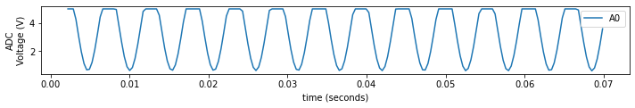

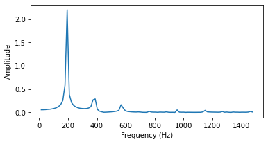

```
Fundamental frequency at 194.08941012346477 Hz, with amplitude 2.2003703117370605 V.
Nyquist frequency as last point in FFT = 1478.0655078633085
```

```python
#
# Imports and code go here...

signals, times = read_and_discard(number_to_read=200, number_to_discard=10)
plot_timestamp(signals, times)#

_ = FFT(signals,times)
```

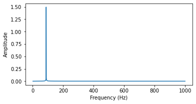

```
Fundamental frequency at 88.0880880880881 Hz, with amplitude 1.4948441956705754 V.
Nyquist frequency as last point in FFT = 1000.0
```

```python
times = time
freq, amp, phase = FFT(test_signal, times)
```

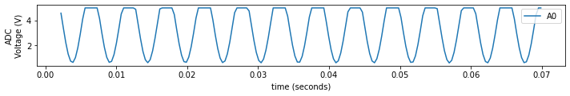

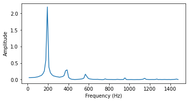

```
Fundamental frequency at 194.08941012346477 Hz, with amplitude 2.194689989089966 V.
Nyquist frequency as last point in FFT = 1478.0655078633085
```

```python
signals, times = read_and_discard(number_to_read=200, number_to_discard=10)
plot_timestamp(signals, times)
freq, amp, phase = FFT(signals, times)
```

Assuming we have acquired the correct signal (all wires well connected, etc.), we are able to extract useful information; the frequency, and amplitude of the fundamental Fourier component of the signal.

Increase the number of samples such that you are able to accurately determine the frequency of the signal - think about the accuracy that you require, and how many samples are needed for a given Nyquist frequency in order to achieve this accuracy.

**NOTE** that if you find that your measured signals here are not reasonably clean sinusoidal waveforms at the correct specified frequency, and the FFTs still have noticeable higher harmonic components, it may be that your signal amplitude is too high and is causing the measurement to be 'clipped' at the 5 V maximum of the Arduino analog input. Try reducing the amplitude slightly until you find the waveform is not distorted.

Try generating a **square-wave** signal instead, by pressing the square button on the top right of the signal generator. You should see several higher harmonics in the FFT spectrum - these correspond to the amplitudes of the Fourier series expansion of a square wave.

```python
from scipy.signal import find_peaks

maxima, _ = find_peaks(amp, height=0.02)
fft_freqs, fft_amps, fft_phases = freq[maxima], amp[maxima], phase[maxima]

print('Peak frequencies (Hz):', fft_freqs)
print('Peak amplitudes (V):', fft_amps)
print('Peak phases (radian):', fft_phases)
```

```
Peak frequencies (Hz): [ 194.08941012  388.17882025  567.33827575  761.42768587  955.51709599
 1149.60650612]
Peak amplitudes (V): [2.19469    0.2945341  0.1643769  0.02263753 0.05217794 0.04119737]
Peak phases (radian): [ 2.1711218 -0.3546481  3.3279238  3.963221   1.3862284  1.9751204]
```

We can then use these peak values to reconstruct our original signal using a sum of sinusoidal components, each corresponding to one of the peaks in the FFT. You should hopefully find that the original signal is constructed fairly well.

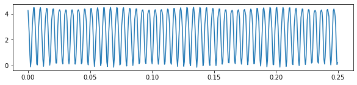

```python
def sinusoid(freq, amp, phase, time):
    return amp*numpy.sin(2*numpy.pi*freq*time + phase)

reconstructed = 2.5*numpy.ones_like(time) # signal offset by 2.5 V

for f, a, ph in zip(fft_freqs, fft_amps, fft_phases):
    reconstructed += sinusoid(f, a, ph, time)

plt.figure(figsize=(10,2))
plt.plot(time[:500], reconstructed[:500])
plt.show()
```

This provides an example of how the FFT can be used to find information from signals.

As for the last session, **save your notebook and export it to HTML format (File -> Download as -> HTML).** Saving as HTML will include all outputs (graphs etc) in a 'frozen' format; keep a copy so that you can refer to it while completing the homework assignement (or view it again later) and there is no chance that you can 'lose' the output by accidentally re-running code cells.

It is again a good idea to leave your Arduino in a 'known' state with benign code uploaded - the `Blink` sketch is a good choice.